# In-Class Models 1

David Murillo

November 1, 2022

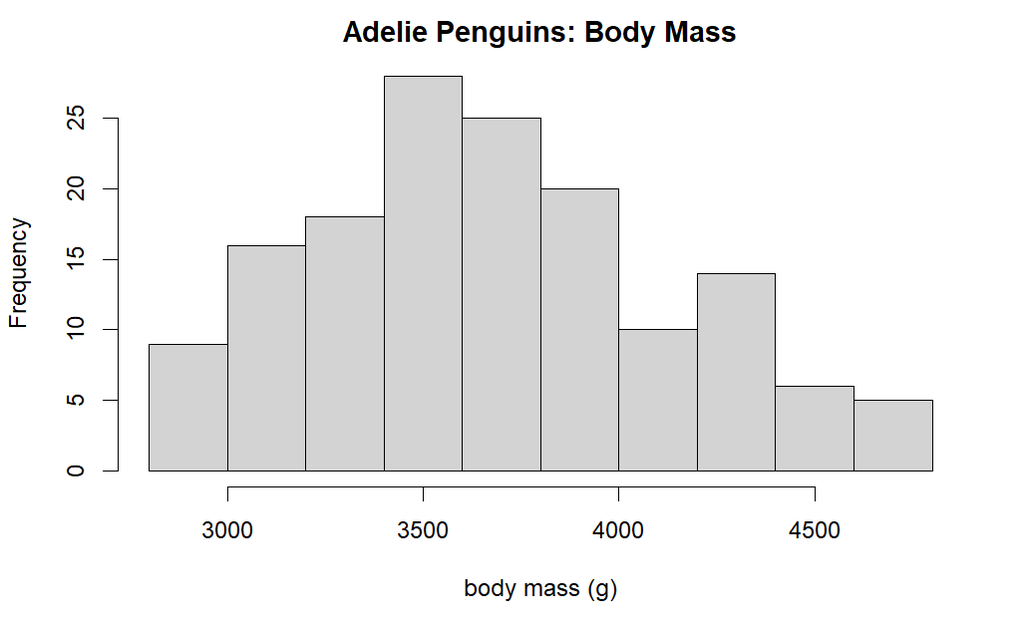

```r
require(palmerpenguins)
dat_ade = droplevels(subset(penguins, species == "Adelie"))

hist(dat_ade$body_mass_g, main = "Adelie Penguins: Body Mass", xlab = "body mass (g)")
```

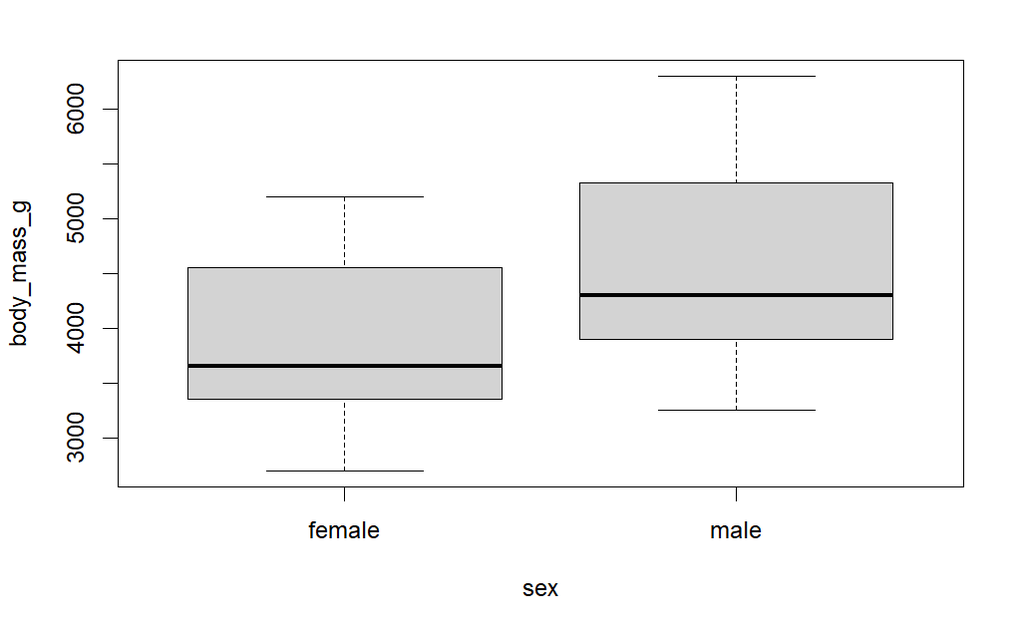

```r
boxplot(body_mass_g ~ sex, data= penguins)
```

# **Q1 (2 pts.): Create separate boxplots of body mass for male and female Adelie penguins. Your boxplots do not have to be in the same panel like mine. Show the R-code you used to make the plots.**

[figure not shown]

```r
Adelie <- droplevels(subset(penguins, species == "Adelie"))

Adelie_female <- droplevels(subset(penguins, sex == "female"))

Adelie_male <- droplevels(subset(penguins, sex == "male"))

par(mfrow = c(1,2))

boxplot(Adelie_female$body_mass_g, main = "Body mass of Adelie female",
        ylab = "Body mass", xlab= "")

boxplot(Adelie_male$body_mass_g, main = "Body mass of Adelie male",
        ylab = "Body mass", xlab= "")
```

- **Q2 (2 pts.): Perform a one-sample t-test of the alternative hypothesis that female Adelie penguins have a body mass different from zero grams. Note that this is a very silly alternative hypothesis. Is this a one- or two-tailed test? Show your R-code.**

*Answer: Is a two tailed test*

```r
t.test(Adelie_female$body_mass_g, alternative = "two.sided", mu= 0 )
```

```
    One Sample t-test

data:  Adelie_female$body_mass_g
t = 74.473, df = 164, p-value < 2.2e-16
alternative hypothesis: true mean is not equal to 0
95 percent confidence interval:
 3759.871 3964.675
sample estimates:
mean of x
 3862.273
```

- **Q4 (2 pts.): Now, conduct a slightly less silly test: perform a one-sample t-test of the alternative hypothesis that male Adelie penguins have a mean body mass greater than 4000 grams. Is this a one- or two-tailed test?**

*Answer: Is one tailed test*

```r
t.test(Adelie_male$body_mass_g, alternative = "greater", mu = 4000)
```

```
    One Sample t-test

data:  Adelie_male$body_mass_g
t = 8.98, df = 167, p-value = 2.755e-16
alternative hypothesis: true mean is greater than 4000
95 percent confidence interval:
 4445.174      Inf
sample estimates:
mean of x
 4545.685
```

- **Q5 (1 pt.): Describe your conclusions based on the p-value of the t-test.**
- **Q6 (2 pts.): Conduct a two-sample t-test of the alternative hypothesis that male and female Adelie penguins have different mean body masses. Show your r-code.**

*Answer:*

```r
t.test(Adelie_male$body_mass_g, Adelie_female$body_mass_g)
```

```
    Welch Two Sample t-test

data:  Adelie_male$body_mass_g and Adelie_female$body_mass_g
t = 8.5545, df = 323.9, p-value = 4.794e-16
alternative hypothesis: true difference in means is not equal to 0
95 percent confidence interval:
 526.2453 840.5783
sample estimates:
mean of x mean of y
 4545.685  3862.273
```

- **Q7 (1 pt.): Describe your conclusions based on the p-value of the t-test.**
- **Q8 (2 pts.): Conduct a two-sample (one-tailed) t-test of the directional alternative hypothesis that male Adelie penguins are heavier than females.**

```r
t.test(Adelie_male$body_mass_g, Adelie_female$body_mass_g, alternative = "greater")
```

```
    Welch Two Sample t-test

data:  Adelie_male$body_mass_g and Adelie_female$body_mass_g
t = 8.5545, df = 323.9, p-value = 2.397e-16
alternative hypothesis: true difference in means is greater than 0
95 percent confidence interval:
 551.6295      Inf
sample estimates:
mean of x mean of y
 4545.685  3862.273
```

- **Q9 (2 pts.): Conduct a two-sample (one-tailed) t-test of the directional alternative hypothesis that male Adelie penguins are lighter than females.**

```r
t.test(Adelie_male$body_mass_g, Adelie_female$body_mass_g, alternative = "less")
```

```
    Welch Two Sample t-test

data:  Adelie_male$body_mass_g and Adelie_female$body_mass_g
t = 8.5545, df = 323.9, p-value = 1
alternative hypothesis: true difference in means is less than 0
95 percent confidence interval:
     -Inf 815.1941
sample estimates:
mean of x mean of y
 4545.685  3862.273
```